# Nuuk Fjord: Drivers of shrub abundance - development of beta-binomial mixture model

Jonathan von Oppen

13/05/2020

## Dependencies

Packages included:

- tidyverse - for convenient code flow, data wrangling and plotting
- rjags & R2jags - to link JAGS and R
- skimr - for data summary
- Rmarkdown - to produce this neat little documentation

```r
# load pacman package from the repository, if you do not already have it
if (!require('pacman')) install.packages('pacman', repos="https://cloud.r-project.org")
pacman::p_load(tidyverse, # set of packages for data manipulation, exploration and visualisation
               rjags,     # to link JAGS and R
               R2jags,    # to link JAGS and R
               skimr,     # for quick dataframe inspection
               rmarkdown) # for R Markdown formatting
```

## Import data

```r
env_cov_bio <- read.csv("../../data/nuuk_env_cover_plotgroups.csv", header = T)
```

```r
skim(env_cov_bio)
```

```
-- Data Summary ------------------------
                           Values
Name                       env_cov_bio
Number of rows             621
Number of columns          53
_______________________
Column type frequency:
  factor                   3
  numeric                  50
________________________
Group variables            None

-- Variable type: factor ---------------------------------------------------------------------------------------------
# A tibble: 3 x 6
  skim_variable         n_missing complete_rate ordered n_unique top_counts
```

[output cut: 111 more lines]

## Selection of variables relevant for analysis

including predictors

- Information on site, plot group, sampling location (lat, lon, altitude), sampling year
- downscaled CHELSA predictors (*[…]_ts_XX*)
- solar radiation index (SRI, following [Keating et al. 2007](http://www.bioone.org/doi/abs/10.2193/2006-359), yet to come), slope (erosion measure) & moisture availability (-> Jakob, yet to come)
- taxon (see above for levels)
- competition pressure in the community (as summed abundance of taller-growing shrub species within a plot, averaged within plot groups)

and response variable

- cover (as relative no. hits per plot, averaged within plot groups)

```r
env_cov_bio_sub <- env_cov_bio %>%
  select(site_alt_plotgroup_id, site, site_alt_id, year, long, lat,  # plot info / metadata
  ends_with("_ts_10"),   # CHELSA predictors averaged over 10-year period prior to study year
  inclin_down, twi_90m, #sri,
  #mean_summ_ndvi_yos, cv_mean_summ_ndvi_2001_to_yos, Perc_dist_coast_lines,   # environmental data
  taxon, cover, compet)   # taxon, cover response, competition pressure
```

```
select: dropped 35 variables (alt, plotgroup, tempjja_ts_5, tempjja_ts_15, tempjja_ts_20, 㠼㸵)
```

```r
head(env_cov_bio_sub)
```

|  | site_alt_plotgroup_id | site | site_alt_id | year | long | lat | tempjja_ts_10 | tempmax_ts_10 | tempmin_ts_10 | tempcont_ts_10 | precipjja_ts_10 | precipjfmam_ts_10 | precipmam_ts_10 | inclin_down | twi_90m | taxon | cover | compet |
| --- | --- | --- | --- | --- | --- | --- | --- | --- | --- | --- | --- | --- | --- | --- | --- | --- | --- | --- |
| 1 | 1_100_1 | 1 | 1_100 | 2011 | -51.80355 | 64.23418 | 10.22318 | 11.34972 | -11.97173 | 23.32146 | 163.0041 | 213.438 | 105.3599 | 17.33333 | 5.413612 | Betula nana | 0.0000000 | 0.00000 |
| 2 | 1_100_1 | 1 | 1_100 | 2011 | -51.80355 | 64.23418 | 10.22318 | 11.34972 | -11.97173 | 23.32146 | 163.0041 | 213.438 | 105.3599 | 17.33333 | 5.413612 | Cassiope tetragona | 0.0000000 | 14.16667 |
| 3 | 1_100_1 | 1 | 1_100 | 2011 | -51.80355 | 64.23418 | 10.22318 | 11.34972 | -11.97173 | 23.32146 | 163.0041 | 213.438 | 105.3599 | 17.33333 | 5.413612 | Empetrum nigrum | 0.5466667 | 0.50000 |
| 4 | 1_100_1 | 1 | 1_100 | 2011 | -51.80355 | 64.23418 | 10.22318 | 11.34972 | -11.97173 | 23.32146 | 163.0041 | 213.438 | 105.3599 | 17.33333 | 5.413612 | Rhododendron groenlandicum | 0.0000000 | 0.00000 |
| 5 | 1_100_1 | 1 | 1_100 | 2011 | -51.80355 | 64.23418 | 10.22318 | 11.34972 | -11.97173 | 23.32146 | 163.0041 | 213.438 | 105.3599 | 17.33333 | 5.413612 | Rhododendron tomentosum | 0.0000000 | 0.00000 |
| 6 | 1_100_1 | 1 | 1_100 | 2011 | -51.80355 | 64.23418 | 10.22318 | 11.34972 | -11.97173 | 23.32146 | 163.0041 | 213.438 | 105.3599 | 17.33333 | 5.413612 | Phyllodoce caerulea | 0.0000000 | 14.16667 |

### Make exploratory plots for relationships between predictors and cover

Let’s create some plots to show possible effects of predictor variables on cover for the different species:

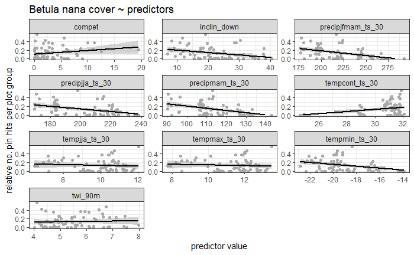

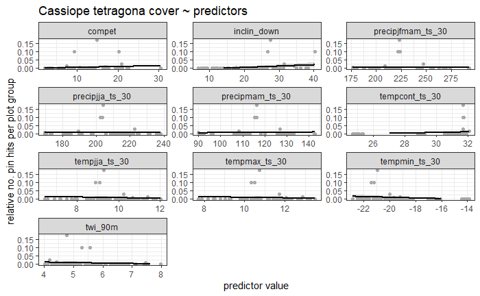

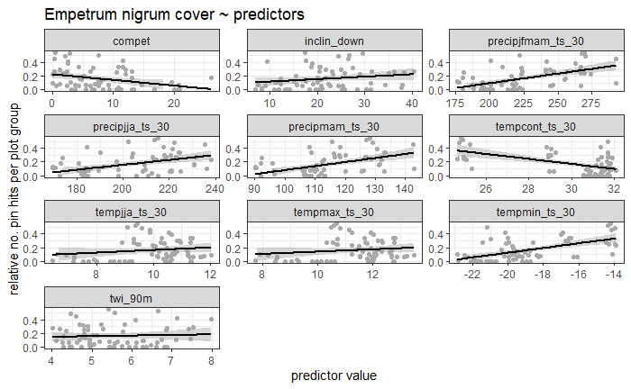

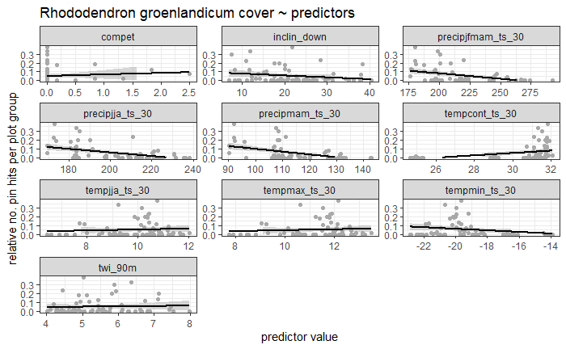

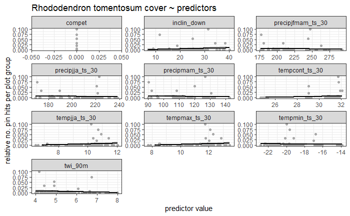

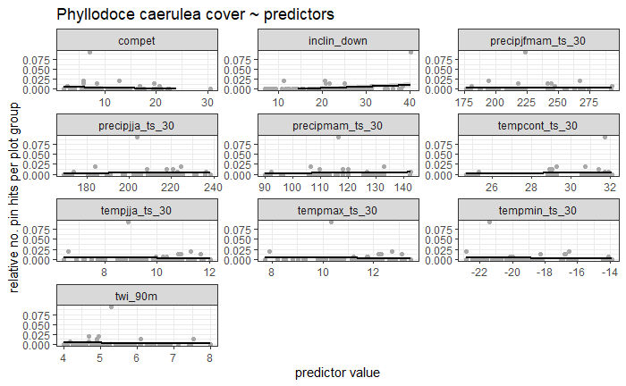

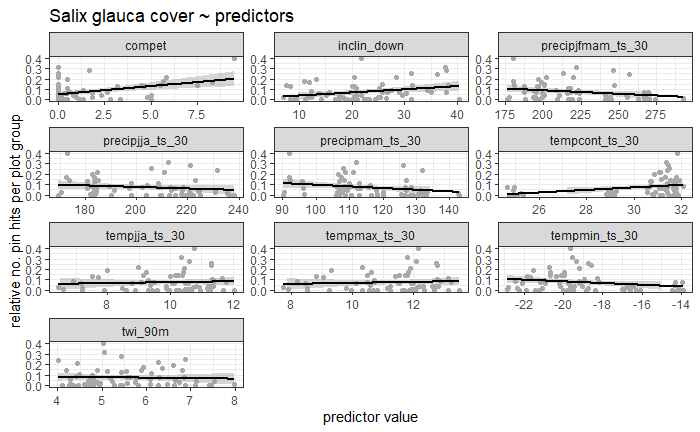

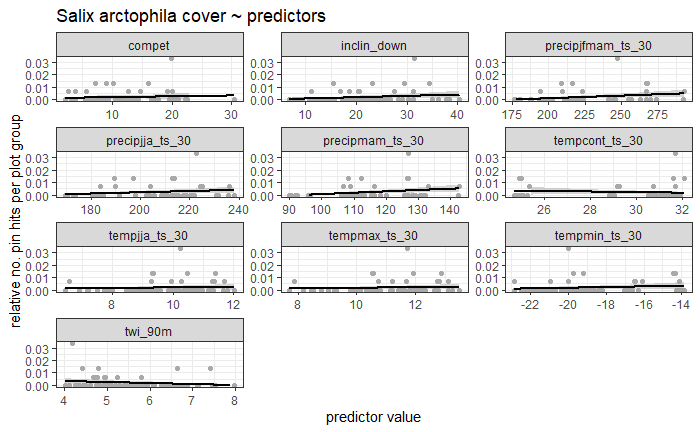

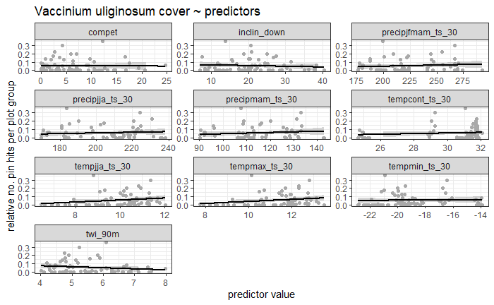

```r
env_cov_bio.long <- env_cov_bio %>%
  select(taxon,
         inclin_down,
         ends_with("ts_30"),
         twi_90m,
         compet,
         cover) %>%
  # pivot to long format
  pivot_longer(cols = c(inclin_down,
                           ends_with("ts_30"),
                           twi_90m,
                           compet),
               names_to = "predictor",
               values_to = "pred_value")

# build function
pred.plot.grid <- function(df){

  taxa <- df %>% pull(taxon) %>% unique() %>% as.character()

  for(taxon_nr in 1:length(taxa)){
    plot <- ggplot(data = df %>% filter(taxon == taxa[taxon_nr]),
                   aes(y = cover, group = taxon)) +
      geom_point(aes(x = pred_value), colour = "darkgrey") +
      geom_smooth(aes(x = pred_value), method = "lm", colour = "black", se = TRUE, na.rm = TRUE) +
      facet_wrap(~predictor, scales = "free", ncol = 3) +
      scale_y_continuous("relative no. pin hits per plot group",
                         limits = c(0, max(df %>%
                                             filter(taxon == taxa[taxon_nr]) %>%
                                             pull(cover)))) +
      labs(x = "predictor value") +
      ggtitle(paste0(taxa[taxon_nr], " cover ~ predictors")) +
      theme_bw() +
      theme(legend.position = "none")
    print(plot)
  }
}

# run
pred.plot.grid(env_cov_bio.long)
```

## Multi-species model

### Prepare data for JAGS model

### a) Abundance check & selection of taxa

Only taxa with competition data were included, i.e.

```r
tibble(levels(env_cov_bio_sub$taxon))
```

| levels(env_cov_bio_sub$taxon) |
| --- |
| Betula nana |
| Cassiope tetragona |
| Empetrum nigrum |
| Phyllodoce caerulea |
| Rhododendron groenlandicum |
| Rhododendron tomentosum |
| Salix arctophila |
| Salix glauca |
| Vaccinium uliginosum |

Some of the target taxa showed low abundance for most of the plot groups:

```r
# Summary of zeros per taxon & as percentage of all 69 plotgroups:
env_cov_bio_sub %>% group_by(taxon) %>%
  summarise_at(vars(cover), list(~sum(. == 0))) %>%
  rename(zeros = cover) %>%
  mutate(zeros_perc = zeros/69) %>%
  arrange(desc(zeros))
```

```
group_by: one grouping variable (taxon)
summarise_at: now 9 rows and 2 columns, ungrouped
rename: renamed one variable (zeros)
mutate: new variable 'zeros_perc' with 9 unique values and 0% NA
```

| taxon | zeros | zeros_perc |
| --- | --- | --- |
| Cassiope tetragona | 63 | 0.9130435 |
| Phyllodoce caerulea | 60 | 0.8695652 |
| Rhododendron tomentosum | 59 | 0.8550725 |
| Salix arctophila | 57 | 0.8260870 |
| Rhododendron groenlandicum | 35 | 0.5072464 |
| Vaccinium uliginosum | 25 | 0.3623188 |
| Salix glauca | 18 | 0.2608696 |
| Betula nana | 17 | 0.2463768 |
| Empetrum nigrum | 15 | 0.2173913 |

To improve the chance of model convergence, we removed *Cassiope tetragona* & *Phyllodoce caerulea* (moving down the list):

```r
env_cov_bio_sub <- env_cov_bio_sub[env_cov_bio_sub$taxon %in% c("Cassiope tetragona",
                                                                "Phyllodoce caerulea")==F,] %>%
  droplevels(env_cov_bio_sub$taxon)
head(env_cov_bio_sub, nlevels(env_cov_bio_sub$taxon))
```

|  | site_alt_plotgroup_id | site | site_alt_id | year | long | lat | tempjja_ts_10 | tempmax_ts_10 | tempmin_ts_10 | tempcont_ts_10 | precipjja_ts_10 | precipjfmam_ts_10 | precipmam_ts_10 | inclin_down | twi_90m | taxon | cover | compet |
| --- | --- | --- | --- | --- | --- | --- | --- | --- | --- | --- | --- | --- | --- | --- | --- | --- | --- | --- |
| 1 | 1_100_1 | 1 | 1_100 | 2011 | -51.80355 | 64.23418 | 10.22318 | 11.34972 | -11.97173 | 23.32146 | 163.0041 | 213.438 | 105.3599 | 17.33333 | 5.413612 | Betula nana | 0.0000000 | 0.00000 |
| 3 | 1_100_1 | 1 | 1_100 | 2011 | -51.80355 | 64.23418 | 10.22318 | 11.34972 | -11.97173 | 23.32146 | 163.0041 | 213.438 | 105.3599 | 17.33333 | 5.413612 | Empetrum nigrum | 0.5466667 | 0.50000 |
| 4 | 1_100_1 | 1 | 1_100 | 2011 | -51.80355 | 64.23418 | 10.22318 | 11.34972 | -11.97173 | 23.32146 | 163.0041 | 213.438 | 105.3599 | 17.33333 | 5.413612 | Rhododendron groenlandicum | 0.0000000 | 0.00000 |
| 5 | 1_100_1 | 1 | 1_100 | 2011 | -51.80355 | 64.23418 | 10.22318 | 11.34972 | -11.97173 | 23.32146 | 163.0041 | 213.438 | 105.3599 | 17.33333 | 5.413612 | Rhododendron tomentosum | 0.0000000 | 0.00000 |
| 7 | 1_100_1 | 1 | 1_100 | 2011 | -51.80355 | 64.23418 | 10.22318 | 11.34972 | -11.97173 | 23.32146 | 163.0041 | 213.438 | 105.3599 | 17.33333 | 5.413612 | Salix glauca | 0.0000000 | 0.00000 |
| 8 | 1_100_1 | 1 | 1_100 | 2011 | -51.80355 | 64.23418 | 10.22318 | 11.34972 | -11.97173 | 23.32146 | 163.0041 | 213.438 | 105.3599 | 17.33333 | 5.413612 | Salix arctophila | 0.0000000 | 14.16667 |
| 9 | 1_100_1 | 1 | 1_100 | 2011 | -51.80355 | 64.23418 | 10.22318 | 11.34972 | -11.97173 | 23.32146 | 163.0041 | 213.438 | 105.3599 | 17.33333 | 5.413612 | Vaccinium uliginosum | 0.0200000 | 0.00000 |

### b) adjustion of data structure

Data was ordered by site/altitude/plotgroup and taxon

```r
env_cov_bio_sub <- env_cov_bio_sub[order(env_cov_bio_sub$site_alt_plotgroup_id, env_cov_bio_sub$taxon),]
```

As JAGS is only able to handle numeric input, all variables are assigned a numeric identifier:

```r
env_cov_bio_sub$plotgroup.NUM <- as.numeric(factor(env_cov_bio_sub$site_alt_plotgroup_id, levels=unique(env_cov_bio_sub$site_alt_plotgroup_id)))
env_cov_bio_sub$site.NUM <- as.numeric(factor(env_cov_bio_sub$site, levels = unique(env_cov_bio_sub$site)))
env_cov_bio_sub$taxon.NUM <- as.numeric(factor(env_cov_bio_sub$taxon, levels = unique(env_cov_bio_sub$taxon)))
```

Thus, taxa were coded in alphabetical order as follows:

```r
data.frame(taxon = levels(env_cov_bio_sub$taxon),
                       num = env_cov_bio_sub$taxon.NUM[1:nlevels(env_cov_bio_sub$taxon)])
```

| taxon | num |
| --- | --- |
| Betula nana | 1 |
| Empetrum nigrum | 2 |
| Rhododendron groenlandicum | 3 |
| Rhododendron tomentosum | 4 |
| Salix arctophila | 5 |
| Salix glauca | 6 |
| Vaccinium uliginosum | 7 |

In order to define the level of variation of interest, a unique taxon-plotgroup combination variable was created:

```r
env_cov_bio_sub$taxon_plotgroup <- paste(env_cov_bio_sub$plot.group.name,env_cov_bio_sub$taxon,sep="_")
env_cov_bio_sub$taxon_plotgroup.NUM <- as.numeric(factor(env_cov_bio_sub$taxon_plotgroup, levels = unique(env_cov_bio_sub$taxon_plotgroup)))
```

Numeric predictors were scaled:

```r
num_pred <- env_cov_bio_sub %>% select(ends_with("_ts_10"), matches("sri"),
                                       starts_with("twi"),
                                       matches("compet"))
```

```
select: dropped 14 variables (site_alt_plotgroup_id, site, site_alt_id, year, long, 㠼㸵)
```

```r
for(i in 1:length(num_pred)){
  col <- colnames(num_pred[i])
  env_cov_bio_sub[paste0(col,"C")] <- as.numeric(scale(num_pred[i], scale = TRUE, center = TRUE))
}
```

To account for the range of the cover response ($0 \leq cover \leq 1$), the model needs a mixed structure incorporating a beta distribution (for all continuous values with $0 < cover < 1$) and a binomial distribution (for all discrete values of $cover = \{0, 1\}$). An additional variable *cover_discrete* was introduced to separate the dataset into discrete (= 1) and continuous (= 0) cover values:

```r
env_cov_bio_sub$cover_discrete <- ifelse(env_cov_bio_sub$cover == 1 | env_cov_bio_sub$cover == 0, 1, 0)
y.dis <- env_cov_bio_sub[env_cov_bio_sub$cover_discrete == 1,]
y.cont <- env_cov_bio_sub[env_cov_bio_sub$cover_discrete == 0,]
```

### c) assembling data for model input in a list

JAGS needs data input in list format, so I provided all relevant variables as follows:

```r
shrub_gradient_jags.data <- list(
  UV_plotgroup.tot = env_cov_bio_sub$plotgroup.NUM,
  UV_taxon.tot = env_cov_bio_sub$taxon.NUM[!duplicated(env_cov_bio_sub$taxon_plotgroup.NUM)], #one value per tXpg
  N_sites = length(unique(env_cov_bio_sub$site)),
  N_plotgroups = length(unique(env_cov_bio_sub$site_alt_plotgroup_id)),
  N_taxa = length(unique(env_cov_bio_sub$taxon)),
  N_taxonXplotgroup.tot = length(unique(env_cov_bio_sub$taxon_plotgroup.NUM)),

  # discrete data
  cov.dis = y.dis$cover,
  UV_plotgroup.dis = y.dis$plotgroup.NUM,
  # UV_site.dis = y.dis$site.NUM,
  # year.dis = y.dis$year,
  UV_taxon.dis = y.dis$taxon.NUM,
  # sri.dis = y.dis$sriC,
  compet.dis = y.dis$competC,
  N_discrete = nrow(y.dis),
  N_sites.dis = length(unique(y.dis$site)),
  N_plotgroups.dis = length(unique(y.dis$site_alt_plotgroup_id)),
  UV_taxonXplotgroup.dis = y.dis$taxon_plotgroup.NUM,

  # continuous data
  cov.cont = y.cont$cover,
  UV_plotgroup.cont = y.cont$plotgroup.NUM,
  UV_site.cont = y.cont$site.NUM,
  year.cont = y.cont$year,
  UV_taxon.cont = y.cont$taxon.NUM,
  # sri.cont = y.cont$sriC,
  compet.cont = y.cont$competC,
  N_cont = nrow(y.cont),
  N_sites.cont = length(unique(y.cont$site)),
  N_plotgroups.cont = length(unique(y.cont$site_alt_plotgroup_id)),
  UV_taxonXplotgroup.cont = y.cont$taxon_plotgroup.NUM,

  # environmental predictors -> set target predictor name to env.*
  env.tot = env_cov_bio_sub$tempjja_ts_10C[!duplicated(env_cov_bio_sub$plotgroup.NUM)]#, # one value per tXpg, amt = annual mean temperature = bio_1
)
str(shrub_gradient_jags.data)
```

```
List of 25
 $ UV_plotgroup.tot       : num [1:483] 1 1 1 1 1 1 1 2 2 2 ...
 $ UV_taxon.tot           : num [1:7] 1 2 3 4 5 6 7
 $ N_sites                : int 5
 $ N_plotgroups           : int 69
 $ N_taxa                 : int 7
 $ N_taxonXplotgroup.tot  : int 7
 $ cov.dis                : num [1:226] 0 0 0 0 0 0 0 0 0 0 ...
 $ UV_plotgroup.dis       : num [1:226] 1 1 1 1 1 2 2 2 2 2 ...
 $ UV_taxon.dis           : num [1:226] 1 3 4 5 6 1 3 4 5 7 ...
 $ compet.dis             : num [1:226] -0.755 -0.755 -0.755 1.649 -0.755 ...
 $ N_discrete             : int 226
 $ N_sites.dis            : int 5
 $ N_plotgroups.dis       : int 66
 $ UV_taxonXplotgroup.dis : num [1:226] 1 3 4 5 6 1 3 4 5 7 ...
 $ cov.cont               : num [1:257] 0.5467 0.02 0.2467 0.0733 0.4867 ...
 $ UV_plotgroup.cont      : num [1:257] 1 1 2 2 3 3 4 4 4 4 ...
 $ UV_site.cont           : num [1:257] 1 1 1 1 1 1 1 1 1 1 ...
 $ year.cont              : int [1:257] 2011 2011 2011 2011 2011 2011 2011 2011 2011 2011 ...
 $ UV_taxon.cont          : num [1:257] 2 7 2 6 2 7 2 5 6 7 ...
 $ compet.cont            : num [1:257] -0.67 -0.755 -0.444 -0.755 -0.387 ...
 $ N_cont                 : int 257
 $ N_sites.cont           : int 5
 $ N_plotgroups.cont      : int 69
 $ UV_taxonXplotgroup.cont: num [1:257] 2 7 2 6 2 7 2 5 6 7 ...
 $ env.tot                : num [1:69] -0.322 -0.277 -0.217 -0.388 -0.417 ...
```

…and specified the model:

```r
write("

  model{

    # priors

        for (i in 1:N_taxa){
          intercept[i] ~ dnorm(0,0.0001) # intercept per taxon instead of site-taxon?
        }

      for (i in 1:N_taxa){   # same level as main effect of interest, i.e. taxon X plotgroup # AB - make this slope per taxon (not taxon-plotgroup?)
        b_compet[i] ~ dnorm(0,0.0001)
        # b_slope[i] ~ dnorm(0,0.0001)
        b_sri[i] ~ dnorm(0,0.0001)
      }

      sigma.taxonXplotgroup~dunif(0,100)
      tau.taxonXplotgroup<-1/(sigma.taxonXplotgroup*sigma.taxonXplotgroup)

      for (i in 1:N_taxa){
        b.env.x[i]~dnorm(0, 0.001)
        b.env.x2[i]~dnorm(0, 0.001)
      }

      phi~dgamma(0.1,0.1)

    # LIKELIHOOD for discrete part

      for (i in 1:N_discrete){
        cov.dis[i] ~ dbern(mu[i])
        logit(mu[i]) <- b_compet[UV_taxon.dis[i]]*compet.dis[i] + # slope per taxon NOT per taxon-plotgroup?
                        # b_slope[UV_taxon.dis[i]]*slope.dis[i] +
                        # b_sri[UV_taxon.dis[i]]*sri.dis[i] +
                        b_taxonXplotgroup[UV_taxonXplotgroup.dis[i]] # beta by taxon X plotgroup combination, iterating over plots
      }


    # LIKELIHOOD for continuous part

      for (i in 1:N_cont){
        cov.cont[i] ~ dbeta(p[i], q[i])
        p[i] <- mu2[i] * phi
        q[i] <- (1 - mu2[i]) * phi
        logit(mu2[i]) <- b_compet[UV_taxon.cont[i]]*compet.cont[i] +
                         # b_slope[UV_taxon.cont[i]]*slope.cont[i] +
                         # b_sri[UV_taxon.cont[i]]*sri.cont[i] +
                         b_taxonXplotgroup[UV_taxonXplotgroup.cont[i]] # beta by taxon X plotgroup combination, iterating over plots
      }

      for (j in 1:N_taxonXplotgroup.tot){ # length of total plotgroup per taxon combinations
        b_taxonXplotgroup[j] ~ dnorm(mu.taxonXplotgroup[j],tau.taxonXplotgroup)
        mu.taxonXplotgroup[j] <- intercept[UV_taxon.tot[j]] + # slope per taxon not site-taxon?
                    b.env.x[UV_taxon.tot[j]]*env.tot[j] +
                    b.env.x2[UV_taxon.tot[j]]*(env.tot[j]^2) # add more plotgroup-level predictors
      }


      }
  ","shrub_gradient.jags")
```

After specifying the parameters to be monitored, the model was run:

```r
params <- c("b.env.x","b.env.x2","intercept","b_compet", "b_sri","b_taxonXplotgroup[1]","b_taxonXplotgroup[2]","b_taxonXplotgroup[3]","b_taxonXplotgroup[483]","sigma.taxonXplotgroup","phi")

# run model
model_out.shrub_gradient <- jags(shrub_gradient_jags.data, inits = NULL, params,
                                 model.file = "shrub_gradient.jags", n.chains = 3,
                                 n.iter = 8000, n.burnin = 6000, n.thin=2, DIC=FALSE,
                                 working.directory=NULL, progress.bar = "text")
```

[output not shown]

[output not shown]

```
RUNTIME ERROR:
Cannot get subset b_taxonXplotgroup[483]. Range out of bounds
Can't set monitor. No model!
Can't set monitor. No model!
```

```
Error in update.jags(model, n.iter, ...) : Can't update. No model!
```

**!!! Model crashes !!!** (JvO 06 Apr / 05 May 20)

$\implies$ re-try with breaking up the model for the separate species

## Single-species models

This dataset is a new one containing predictors extracted from downscaled CHELSA climate data.

```r
env_cov_bio <- read.csv("../../data/nuuk_env_cover_plots.csv", header = T)
```

```r
skim(env_cov_bio)
```

```
-- Data Summary ------------------------
                           Values
Name                       env_cov_bio
Number of rows             3726
Number of columns          54
_______________________
Column type frequency:
  factor                   4
  numeric                  50
________________________
Group variables            None

-- Variable type: factor ---------------------------------------------------------------------------------------------
# A tibble: 4 x 6
  skim_variable         n_missing complete_rate ordered n_unique top_counts
```

[output cut: 112 more lines]

### Prepare data for JAGS model

### a) selection of variables relevant for analysis

including predictors

- Information on site, plot, plot group, sampling location (lat, lon, altitude), sampling year
- downscaled CHELSA predictors, averaged over a 30-year period (*[…]_ts_30*)
- solar radiation index (SRI, following [Keating et al. 2007](http://www.bioone.org/doi/abs/10.2193/2006-359), yet to come), slope (erosion measure) & moisture availability (-> Jakob, yet to come)
- taxon (see above for levels)
- competition pressure in the community (as summed abundance of taller-growing shrub species within a plot, averaged within plot groups)

and response variable

```r
env_cov_bio_sub <- env_cov_bio %>%
  select(site_alt_plotgroup_id, plot, site, site_alt_id, year, long, lat,  # plot info / metadata
  ends_with("_ts_30"),   # CHELSA predictors averaged over 10-year period prior to study year
  inclin_down, twi_90m, sri,
  #mean_summ_ndvi_yos, cv_mean_summ_ndvi_2001_to_yos, Perc_dist_coast_lines,   # environmental data
  taxon, cover, compet)   # taxon, cover response, competition pressure
```

```
select: dropped 34 variables (alt, plotgroup, tempjja_ts_5, tempjja_ts_10, tempjja_ts_15, 㠼㸵)
```

```r
head(env_cov_bio_sub)
```

|  | site_alt_plotgroup_id | plot | site | site_alt_id | year | long | lat | tempjja_ts_30 | tempmax_ts_30 | tempmin_ts_30 | tempcont_ts_30 | precipjja_ts_30 | precipjfmam_ts_30 | precipmam_ts_30 | inclin_down | twi_90m | sri | taxon | cover | compet |
| --- | --- | --- | --- | --- | --- | --- | --- | --- | --- | --- | --- | --- | --- | --- | --- | --- | --- | --- | --- | --- |
| 1 | 1_20_1 | P145 | 1 | 1_20 | 2011 | -51.78662 | 64.23933 | 9.352377 | 10.57648 | -14.35101 | 24.92749 | 213.5949 | 267.4649 | 126.8913 | 12 | 6.657241 | 0.9330854 | Betula nana | 0.00 | 5 |
| 2 | 1_20_1 | P145 | 1 | 1_20 | 2011 | -51.78662 | 64.23933 | 9.352377 | 10.57648 | -14.35101 | 24.92749 | 213.5949 | 267.4649 | 126.8913 | 12 | 6.657241 | 0.9330854 | Cassiope tetragona | 0.00 | 23 |
| 3 | 1_20_1 | P145 | 1 | 1_20 | 2011 | -51.78662 | 64.23933 | 9.352377 | 10.57648 | -14.35101 | 24.92749 | 213.5949 | 267.4649 | 126.8913 | 12 | 6.657241 | 0.9330854 | Empetrum nigrum | 0.72 | 5 |
| 4 | 1_20_1 | P145 | 1 | 1_20 | 2011 | -51.78662 | 64.23933 | 9.352377 | 10.57648 | -14.35101 | 24.92749 | 213.5949 | 267.4649 | 126.8913 | 12 | 6.657241 | 0.9330854 | Rhododendron groenlandicum | 0.00 | 0 |
| 5 | 1_20_1 | P145 | 1 | 1_20 | 2011 | -51.78662 | 64.23933 | 9.352377 | 10.57648 | -14.35101 | 24.92749 | 213.5949 | 267.4649 | 126.8913 | 12 | 6.657241 | 0.9330854 | Rhododendron tomentosum | 0.00 | 0 |
| 6 | 1_20_1 | P145 | 1 | 1_20 | 2011 | -51.78662 | 64.23933 | 9.352377 | 10.57648 | -14.35101 | 24.92749 | 213.5949 | 267.4649 | 126.8913 | 12 | 6.657241 | 0.9330854 | Phyllodoce caerulea | 0.00 | 23 |

Predictors don’t always vary between plots within plotgroups - perhaps due to several falling into the same CHELSA grid cell.

Example: plots within site 1, altitude 20, plot group 1: plot P146 is slightly off and therefore has different climate variables than the other ones

```
filter: removed 3,720 rows (>99%), 6 rows remaining
```

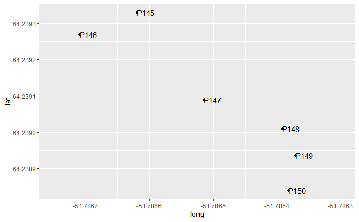

```r
env_cov_bio %>% filter(taxon == "Betula nana" & site_alt_plotgroup_id == "1_20_1") %>%
  ggplot(aes(x = long, y = lat)) +
  geom_point() +
  geom_text(aes(label = plot), hjust = 0.0001) +
  xlim(c(-51.78675, -51.7863))
```

```r
env_cov_bio %>% filter(taxon == "Betula nana" & site_alt_plotgroup_id == "1_20_1") %>%
  select(site_alt_plotgroup_id, plot, tempjja_ts_30)
```

```
filter: removed 3,720 rows (>99%), 6 rows remaining
select: dropped 51 variables (site_alt_id, site, alt, plotgroup, long, 㠼㸵)
```

| site_alt_plotgroup_id | plot | tempjja_ts_30 |
| --- | --- | --- |
| 1_20_1 | P145 | 9.352377 |
| 1_20_1 | P146 | 9.345625 |
| 1_20_1 | P147 | 9.352377 |
| 1_20_1 | P148 | 9.352377 |
| 1_20_1 | P149 | 9.352377 |
| 1_20_1 | P150 | 9.352377 |

### b) adjustion of data structure

Data was ordered by site/altitude/plotgroup and taxon

```r
env_cov_bio_sub <- env_cov_bio_sub[order(env_cov_bio_sub$site_alt_plotgroup_id, env_cov_bio_sub$taxon),]
```

As JAGS is only able to handle numeric input, all variables are assigned a numeric identifier:

```r
env_cov_bio_sub$plotgroup.NUM <- as.numeric(factor(env_cov_bio_sub$site_alt_plotgroup_id,
                                                   levels = unique(env_cov_bio_sub$site_alt_plotgroup_id)))
env_cov_bio_sub$plot.NUM <- as.numeric(factor(env_cov_bio_sub$plot,
                                              levels = unique(env_cov_bio_sub$plot)))
env_cov_bio_sub$site.NUM <- as.numeric(factor(env_cov_bio_sub$site, levels = unique(env_cov_bio_sub$site)))
env_cov_bio_sub$taxon.NUM <- as.numeric(factor(env_cov_bio_sub$taxon, levels = unique(env_cov_bio_sub$taxon)))
```

Taxa were coded as follows:

```r
data.frame(taxon = levels(env_cov_bio_sub$taxon),
           num = unique(env_cov_bio_sub$taxon.NUM))
```

| taxon | num |
| --- | --- |
| Betula nana | 1 |
| Cassiope tetragona | 2 |
| Empetrum nigrum | 3 |
| Phyllodoce caerulea | 4 |
| Rhododendron groenlandicum | 5 |
| Rhododendron tomentosum | 6 |
| Salix arctophila | 7 |
| Salix glauca | 8 |
| Vaccinium uliginosum | 9 |

Numeric predictors were scaled:

```r
num_pred <- env_cov_bio_sub %>% select(ends_with("_ts_30"),
                                       inclin_down,
                                       sri,
                                       starts_with("twi"),
                                       matches("compet"))
```

```
select: dropped 13 variables (site_alt_plotgroup_id, plot, site, site_alt_id, year, 㠼㸵)
```

```r
for(i in 1:length(num_pred)){
  col <- colnames(num_pred[i])
  env_cov_bio_sub[paste0(col,"C")] <- as.numeric(scale(num_pred[i], scale = TRUE, center = TRUE))
}
```

To account for the range of the cover response ($0 \leq cover \leq 1$), the model needs a mixed structure incorporating a beta distribution (for all continuous values with $0 < cover < 1$) and a binomial distribution (for all discrete values of $cover = \{0, 1\}$). An additional variable *cover_discrete* was introduced to separate the dataset into discrete (= 1) and continuous (= 0) cover values:

```r
env_cov_bio_sub$cover_discrete <- ifelse(env_cov_bio_sub$cover == 1 | env_cov_bio_sub$cover == 0, 1, 0)
```

The dataset was then ready to be split up into the species of interest. As a first trial, I focused on *Betula nana*:

```r
# complete Betula nana data
BetNan.tot <- filter(env_cov_bio_sub, taxon == "Betula nana")
```

```
filter: removed 3,312 rows (89%), 414 rows remaining
```

```r
# discrete cover values
BetNan.dis <- filter(BetNan.tot, cover_discrete == 1) # contains only zeros as responses
```

```
filter: removed 191 rows (46%), 223 rows remaining
```

```r
# continuous cover values
BetNan.cont <- filter(BetNan.tot, cover_discrete == 0)
```

```
filter: removed 223 rows (54%), 191 rows remaining
```

### c) assembling data for model input in a list

JAGS needs data input in list format, so I provided all relevant variables as follows:

```r
# Compile data into list ####
shrub_gradient_jags.BetNan.data <- list(
  N_plotgroups = length(unique(BetNan.tot$site_alt_plotgroup_id)),

  # plot level predictors, for discrete...
  cov.dis = BetNan.dis$cover,
  plotgroup.dis = BetNan.dis$plotgroup.NUM, #AB added this
  inclin_down.dis = BetNan.dis$inclin_downC,
  sri.dis = BetNan.dis$sriC,
  twi_90m.dis = BetNan.dis$twi_90mC,
  compet.dis = BetNan.dis$competC,
  N_discrete = nrow(BetNan.dis),

  # ...and continuous part of the data
  cov.cont = BetNan.cont$cover,
  plotgroup.cont = BetNan.cont$plotgroup.NUM, #AB added this
  inclin_down.cont = BetNan.cont$inclin_downC,
  sri.cont = BetNan.cont$sriC,
  twi_90m.cont = BetNan.cont$twi_90mC,
  compet.cont = BetNan.cont$competC,
  N_cont = nrow(BetNan.cont),

  # plot group level predictors
  tempjja.tot = BetNan.tot$tempjja_ts_30C[!duplicated(BetNan.tot$plotgroup.NUM)], # one value per tXpg
  tempmax.tot = BetNan.tot$tempmax_ts_30C[!duplicated(BetNan.tot$plotgroup.NUM)],
  tempmin.tot = BetNan.tot$tempmin_ts_30C[!duplicated(BetNan.tot$plotgroup.NUM)],
  tempcont.tot = BetNan.tot$tempcont_ts_30C[!duplicated(BetNan.tot$plotgroup.NUM)],
  precipjja.tot = BetNan.tot$precipjja_ts_30C[!duplicated(BetNan.tot$plotgroup.NUM)],
  precipjfmam.tot = BetNan.tot$precipjfmam_ts_30C[!duplicated(BetNan.tot$plotgroup.NUM)]
)
str(shrub_gradient_jags.BetNan.data)
```

```
List of 21
 $ N_plotgroups    : int 69
 $ cov.dis         : num [1:223] 0 0 0 0 0 0 0 0 0 0 ...
 $ plotgroup.dis   : num [1:223] 1 1 1 1 1 1 2 2 2 2 ...
 $ inclin_down.dis : num [1:223] -0.153 -0.616 -1.264 0.125 -0.153 ...
 $ sri.dis         : num [1:223] 0.51 0.829 1.034 0.37 0.573 ...
 $ twi_90m.dis     : num [1:223] 0.144 0.144 0.144 -0.384 -0.384 ...
 $ compet.dis      : num [1:223] -0.708 -0.708 -0.708 -0.708 -0.708 ...
 $ N_discrete      : int 223
 $ cov.cont        : num [1:191] 0.08 0.04 0.08 0.12 0.08 0.56 0.24 0.2 0.08 0.12 ...
 $ plotgroup.cont  : num [1:191] 5 5 6 10 10 11 11 11 11 12 ...
 $ inclin_down.cont: num [1:191] -0.893 0.774 0.588 0.588 0.218 ...
 $ sri.cont        : num [1:191] 0.823 -0.248 -0.663 -0.678 -0.192 ...
 $ twi_90m.cont    : num [1:191] 1.78 1.78 1.22 -1.29 -1.29 ...
 $ compet.cont     : num [1:191] -0.477 -0.708 -0.708 -0.708 -0.708 ...
 $ N_cont          : int 191
 $ tempjja.tot     : num [1:69] -0.321 -0.283 -0.226 -0.395 -0.42 ...
 $ tempmax.tot     : num [1:69] -0.414 -0.381 -0.324 -0.486 -0.508 ...
 $ tempmin.tot     : num [1:69] 1.94 2.02 2.04 1.87 1.84 ...
 $ tempcont.tot    : num [1:69] -2.45 -2.52 -2.49 -2.41 -2.39 ...
 $ precipjja.tot   : num [1:69] 0.713 0.866 1.044 0.626 0.593 ...
 $ precipjfmam.tot : num [1:69] 1.5 1.5 1.51 1.44 1.42 ...
```

…and specified the model:

```r
write("

  model{

    # priors

      intercept ~ dnorm(0, 0.0001)

      b.compet ~ dnorm(0, 0.0001)
      b.sri ~ dnorm(0, 0.0001)
      b.inclin_down ~ dnorm(0, 0.0001)
      b.twi_90m ~ dnorm(0, 0.0001)

      sigma.plotgroup ~ dunif(0,100)
      tau.plotgroup <- 1/(sigma.plotgroup * sigma.plotgroup)

      b.tempjja.x ~ dnorm(0, 0.001)
      b.tempjja.x2 ~ dnorm(0, 0.001)
      b.tempmax.x ~ dnorm(0, 0.001)
      b.tempmax.x2 ~ dnorm(0, 0.001)
      b.tempmin.x ~ dnorm(0, 0.001)
      b.tempmin.x2 ~ dnorm(0, 0.001)
      b.tempcont.x ~ dnorm(0, 0.001)
      b.tempcont.x2 ~ dnorm(0, 0.001)
      b.precipjja.x ~ dnorm(0, 0.001)
      b.precipjja.x2 ~ dnorm(0, 0.001)
      b.precipjfmam.x ~ dnorm(0, 0.001)
      b.precipjfmam.x2 ~ dnorm(0, 0.001)

      phi ~ dgamma(0.1, 0.1)


    # LIKELIHOOD for discrete part

      for (i in 1:N_discrete){
        cov.dis[i] ~ dbern(mu[i])
        logit(mu[i]) <- b_plotgroup[plotgroup.dis[i]] + #AB added this, ~= random effect of plot group
                        b.compet * compet.dis[i] +
                        b.inclin_down * inclin_down.dis[i] +
                        b.twi_90m * twi_90m.dis[i] +
                        b.sri * sri.dis[i]
      }


    # LIKELIHOOD for continuous part

      for (i in 1:N_cont){
        cov.cont[i] ~ dbeta(p[i], q[i])
        p[i] <- mu2[i] * phi
        q[i] <- (1 - mu2[i]) * phi
        logit(mu2[i]) <- b_plotgroup[plotgroup.cont[i]] + #AB added this, ~= random effect of plot group
                        b.compet * compet.cont[i] +
                        b.inclin_down * inclin_down.cont[i] +
                        b.twi_90m * twi_90m.cont[i] +
                        b.sri * sri.cont[i]
      }

      for (j in 1:N_plotgroups){ # length of total plotgroups
        b_plotgroup[j] ~ dnorm(mu.plotgroup[j],tau.plotgroup)
        mu.plotgroup[j] <- intercept +

                    # plot group level predictors, linear and quadratic term
                    b.tempjja.x * tempjja.tot[j] +
                    b.tempjja.x2 * (tempjja.tot[j]^2) +
                    b.tempmax.x * tempmax.tot[j] +
                    b.tempmax.x2 * (tempmax.tot[j]^2) +
                    b.tempmin.x * tempmin.tot[j] +
                    b.tempmin.x2 * (tempmin.tot[j]^2) +
                    b.tempcont.x * tempcont.tot[j] +
                    b.tempcont.x2 * (tempcont.tot[j]^2) +
                    b.precipjja.x * precipjja.tot[j] +
                    b.precipjja.x2 * (precipjja.tot[j]^2) +
                    b.precipjfmam.x * precipjfmam.tot[j] +
                    b.precipjfmam.x2 * (precipjfmam.tot[j]^2)
      }


      }
  ","shrub_gradient.BetNan.jags")
```

After specifying the parameters to be monitored, the model was run:

```r
params <- c("intercept",
            "b.tempjja.x", "b.tempjja.x2",
            "b.tempmax.x", "b.tempmax.x2",
            "b.tempmin.x", "b.tempmin.x2",
            "b.tempcont.x", "b.tempcont.x2",
            "b.precipjja.x", "b.precipjja.x2",
            "b.precipjfmam.x", "b.precipjfmam.x2",
            "b.compet",
            "b.inclin_down",
            "b.sri",
            "b.twi_90m",
            "b_plotgroup[1]","b_plotgroup[2]","b_plotgroup[3]","b_plotgroup[63]","sigma.plotgroup","phi")

# run model
model_out.shrub_gradient.BetNan <- jags(shrub_gradient_jags.BetNan.data, inits = NULL, params,
                                 model.file = "shrub_gradient.BetNan.jags", n.chains = 3,
                                 n.iter = 8000, n.burnin = 6000, n.thin=2, DIC=FALSE,
                                 working.directory=NULL, progress.bar = "text")
```

[output not shown]

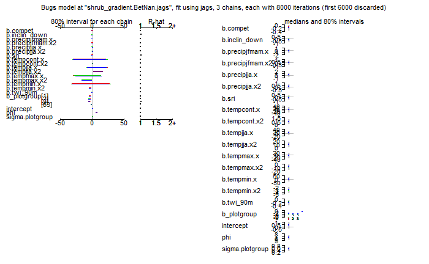

```r
plot(model_out.shrub_gradient.BetNan) #check convergence, etc.
```

[repeat with other species] [repeat with 0 filtered out]